Progetto personale

VIIRS · griglia 500 m · ogni anno dal 2013

# Il Molise di notte

Ogni notte un satellite misura la luce emessa da ogni cella di 500 metri del territorio. Le composizioni annuali VIIRS, dal 2013 al 2022, raccontano dove il Molise si accende: qui una cella conta come «accesa» sopra 1 nW/cm²/sr.

136comuni

109in area interna (80%)

17.842celle da 500 m

+35%celle accese dal 2013

scorri ▼

2013 ↔ 2022

## Dieci anni in una mappa

Trascina il cursore: a sinistra il Molise del **2013**, a destra quello del **2022**. Stessa inquadratura, stessa scala di colore: le celle accese sopra la soglia passano da **3.909 a 5.278** (+35%).

[figure not shown]

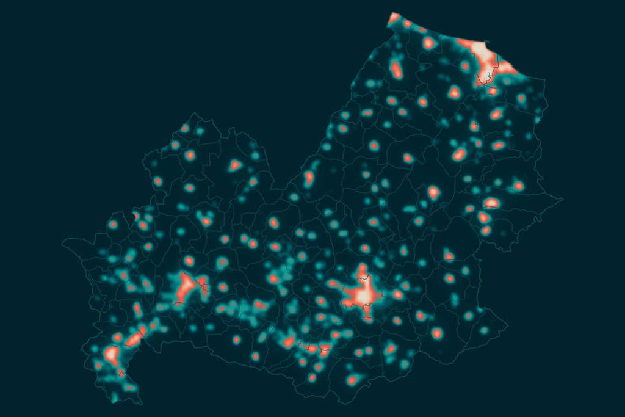

↔

2013 2022

Radianza in scala logaritmica; scala colori identica nelle due annate.

comune per comune

## 136 comuni, una storia ciascuno

Il colore misura la **variazione delle celle accese fra 2013 e 2022**. Passa il mouse (o tocca) un comune per la sua scheda: serie annuale, classe SNAI e finanziamenti della Strategia Aree Interne.

evidenzia i 29 comuni finanziati SNAI

Variazione celle accese 2013→2022

−25% 0 +50% ≥+125%

[figure not shown]

Sfiora o tocca un comune; un clic fuori dai confini riporta alla regione.

celle accese, 2013 → 2022

Classi SNAI 2014–2020; «finanziato» = primo finanziamento fra il 2014 e il 2021 (29 comuni; coorti: 14 nel 2018, 12 nel 2020, 3 nel 2021). Importi OpenCoesione su tutti gli anni disponibili: 54,3 milioni di euro in regione.

la traiettoria

## Un decennio di celle accese

### Molise, celle accese

celle da 500 m sopra 1 nW/cm²/sr

### Finanziati e non, indice 2013 = 100

29 finanziati SNAI 107 non finanziati di cui 80 interni

dove si accende di più

## I dieci comuni con più celle nuove

Differenza fra le celle accese nel 2022 e nel 2013: guida il basso Molise adriatico, con **Montenero di Bisaccia** (+69 celle) e **Campomarino** (+65).

1. Montenero di Bisaccia CB +69

   127 → 196 celle accese (+54,3%)
2. Campomarino CB +65

   147 → 212 celle accese (+44,2%)
3. Guglionesi CB +59

   77 → 136 celle accese (+76,6%)
4. Larino CB +41

   88 → 129 celle accese (+46,6%)
5. Vinchiaturo CB +41

   69 → 110 celle accese (+59,4%)
6. Rotello CB +40

   33 → 73 celle accese (+121,2%)
7. Bojano CBfinanziato SNAI +37

   69 → 106 celle accese (+53,6%)
8. Ferrazzano CB +31

   34 → 65 celle accese (+91,2%)
9. Agnone ISfinanziato SNAI +30

   26 → 56 celle accese (+115,4%)
10. Trivento CB +29

    42 → 71 celle accese (+69,0%)

non finanziato finanziato SNAI